# proyecto final

nombre

2023-11-27

1. Debes fusionar ambos dataframes, usando como variable de enlace “track_id”, es decir mantener las canciones que coincidan en esta variable para ambos dataframes, conservando unicamente las columnas “track_id” y “genre_top” del dataset tracks.csv y todas las columnas de metrics_music.csv.

```r
t= read.csv("tracks.csv")
me=read.csv("metrics_music.csv")
t_gen= subset(t, select = c("track_id", "genre_top"))
dataFrame= merge(t_gen , me, by = "track_id", all = FALSE)
head(dataFrame)
```

```
##   track_id genre_top  X acousticness danceability     energy instrumentalness
## 1        2   Hip-Hop  0    0.4166752    0.6758940 0.63447627      0.010628068
## 2        3   Hip-Hop  1    0.3744078    0.5286431 0.81746113      0.001851103
## 3        5   Hip-Hop  2    0.0435669    0.7455659 0.70146999      0.000696799
## 4      134   Hip-Hop  4    0.4522173    0.5132381 0.56040993      0.019442694
## 5      153      Rock 13    0.9883055    0.2556609 0.97977379      0.973005724
## 6      154      Rock 14    0.9701349    0.3529461 0.02385156      0.957112885
##     liveness speechiness   tempo    valence
## 1 0.17764657  0.15931006 165.922 0.57666099
## 2 0.10587994  0.46181813 126.957 0.26924024
## 3 0.37314331  0.12459534 100.260 0.62166122
## 4 0.09656669  0.52551938 114.290 0.89407227
## 5 0.12134200  0.05173976  90.241 0.03401787
## 6 0.11326072  0.03217676  53.758 0.03563156
```

2. Crear un gráfico de correlaciones de las variables e interpretar los resultados. sugerencia usar el paquete corrplot.

```r
library(dplyr)
```

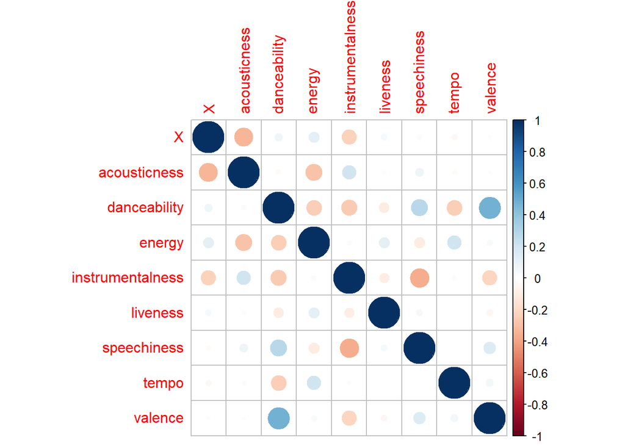

```r
datosCoor =select(dataFrame, -track_id, -genre_top)
matriz_cor <- cor(datosCoor)
library(corrplot)
corrplot(matriz_cor)
```

3. Crear un análisis de componentes principales.

```r
library(FactoMineR)
```

```r
info_dataFrame <- select_if(datosCoor , is.numeric)
normalizados <- scale(info_dataFrame)
pca_1<- PCA(normalizados,graph = FALSE, ncp = 6)
```

3.1. Crear un gráfico Biplot e interpretarlo (colocar el tipo de género de la canción (genre_top) como color de los puntos)

```r
library(factoextra)
```

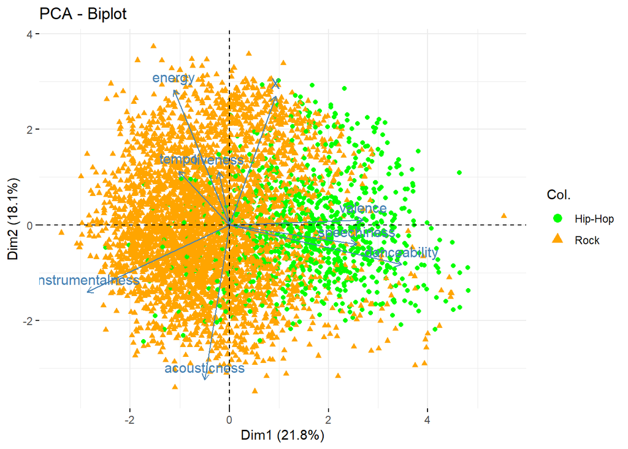

```r
iden<- c("Hip-Hop" = "green", "Rock" = "orange")
fviz_pca_biplot(pca_1, geom.ind = "point", col.ind = dataFrame$genre_top,
                palette = iden)
```

3.2. Crear un gráfico del codo (screeplot) y basado en esto expresar el número de componentes a mantener en el modelo ¿Se puede concluir algo del screeplot?

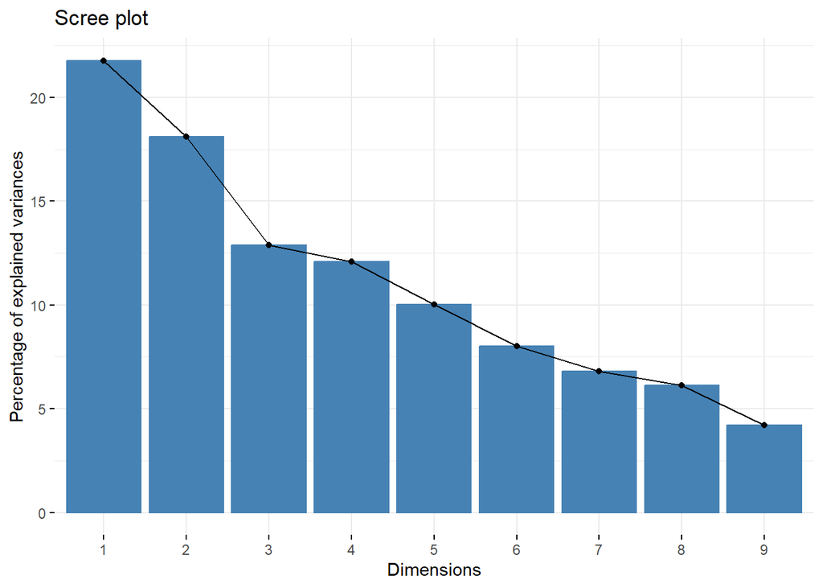

```r
fviz_screeplot(pca_1)
```

3.3. Crear una tabla con el porcentaje de varianza acumulado explicado por las componentes principales, comentar esta tabla.

```r
var<- pca_1$eig[, "cumulative percentage of variance"]
var_table<- data.frame(Componente = 1:length(var),
                    "varianza acumuluada" = var)
print(var_table)
```

```
##        Componente varianza.acumuluada
## comp 1          1            21.78224
## comp 2          2            39.88116
## comp 3          3            52.76124
## comp 4          4            64.83908
## comp 5          5            74.86465
## comp 6          6            82.86828
## comp 7          7            89.67015
## comp 8          8            95.80082
## comp 9          9           100.00000
```

4. Crear los datasets de entrenamiento y prueba, fijando la semilla de programación en 2023.

```r
set.seed(2023)
dataFrame=dataFrame[,-1]
porcentaje= sample(nrow(dataFrame), nrow(dataFrame)*0.7)
entrenamiento =dataFrame[porcentaje, ]
prueba = dataFrame[-porcentaje, ]
```

5. Crear un arbol de decisión para clasificar las canciones según su genero (genre_top) usando los datos de entrenamiento. 5.1. Decidir las variables que ingresarán al modelo

```r
library(rpart)
library(rpart.plot)
decision_a= rpart(genre_top ~ X + acousticness + danceability + instrumentalness +
                          liveness + speechiness, data =  entrenamiento )
prediccion <- predict(decision_a,newdata = prueba, type = "class")
```

5.2. Calcular las métricas de desempeño del modelo (Sugerencia: usar la función confusionMatrix() del paquete caret)

```r
library(ISLR)
library(ranger)
library(caret)
prueba$genre_top=as.factor(prueba$genre_top)
entrenamiento$genre_top=as.factor(entrenamiento$genre_top)
matrizC<- confusionMatrix(prediccion, prueba$genre_top)
print(matrizC)
```

```
## Confusion Matrix and Statistics
##
##           Reference
## Prediction Hip-Hop Rock
##    Hip-Hop     164   35
##    Rock         97 1145
##
##                Accuracy : 0.9084
##                  95% CI : (0.8923, 0.9228)
##     No Information Rate : 0.8189
##     P-Value [Acc > NIR] : < 2e-16
##
##                   Kappa : 0.6597
##
##  Mcnemar's Test P-Value : 1.1e-07
##
##             Sensitivity : 0.6284
##             Specificity : 0.9703
##          Pos Pred Value : 0.8241
##          Neg Pred Value : 0.9219
##              Prevalence : 0.1811
##          Detection Rate : 0.1138
##    Detection Prevalence : 0.1381
##       Balanced Accuracy : 0.7993
##
##        'Positive' Class : Hip-Hop
##
```

5.3. Graficar el árbol de decisión resultante

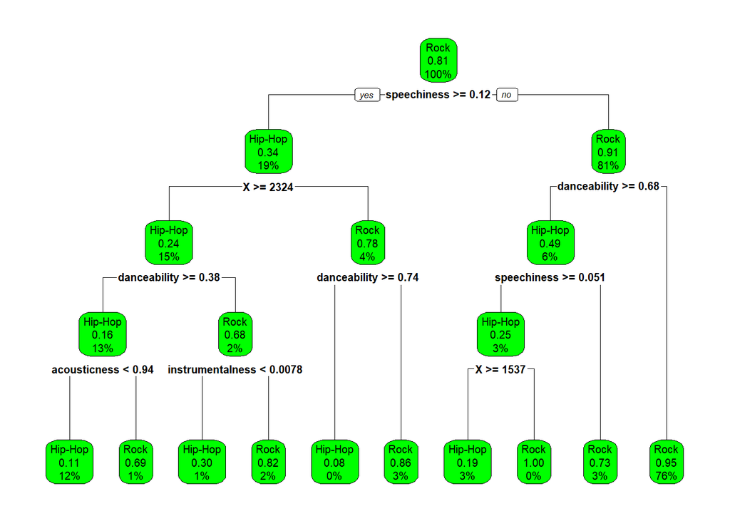

```r
grafico_arbol <- rpart.plot(decision_a,box.palette = "green")
```

5.4. ¿Vale la pena calcular el accuracy para este modelo? 5.5. Analizar la matriz de confusión y comentar los resultados

6. Crear un modelo de regresión logística

```r
entrenamiento$genre_top <- ifelse(entrenamiento$genre_top  == "Hip-Hop", 0, 1)
prueba$genre_top <- ifelse(prueba$genre_top  == "Hip-Hop", 0, 1)

mr<- glm(genre_top ~ X + acousticness + danceability + instrumentalness +
                          liveness + speechiness+ tempo , data = entrenamiento, family = "binomial")
pm<- predict(mr, newdata = prueba, type = "response")

predc<- ifelse(pm > 0.5, 1, 0)
predc<- as.factor(predc)
prueba$genre_top=as.factor(prueba$genre_top)
```

6.1.Calcular las métricas de desempeño del modelo (Sugerencia: usar la función confusionMatrix() del paquete caret)

```r
metrica<- confusionMatrix(predc, prueba$genre_top)
print(metrica)
```

```
## Confusion Matrix and Statistics
##
##           Reference
## Prediction    0    1
##          0  148   39
##          1  113 1141
##
##                Accuracy : 0.8945
##                  95% CI : (0.8775, 0.9099)
##     No Information Rate : 0.8189
##     P-Value [Acc > NIR] : 1.229e-15
##
##                   Kappa : 0.6003
##
##  Mcnemar's Test P-Value : 3.198e-09
##
##             Sensitivity : 0.5670
##             Specificity : 0.9669
##          Pos Pred Value : 0.7914
##          Neg Pred Value : 0.9099
##              Prevalence : 0.1811
##          Detection Rate : 0.1027
##    Detection Prevalence : 0.1298
##       Balanced Accuracy : 0.7670
##
##        'Positive' Class : 0
##
```

6.2. Analizar la matriz de confusión y comentar los resultados

6.3.Comparar los resultados de la regresión logística con el árbol de decisión. Comentar los hallazgos.

```r
info_50= sample(nrow(dataFrame), nrow(dataFrame)*0.5)
new_entrenamiento =dataFrame[info_50,]
nuew_prueba= dataFrame[-info_50, ]
```

7.1.arbol de decision

```r
decision_new= rpart(genre_top ~ X + acousticness + danceability + instrumentalness +
                          liveness + speechiness, data =  new_entrenamiento )
prediccion_new <- predict(decision_new,newdata = nuew_prueba, type = "class")

nuew_prueba$genre_top=as.factor(nuew_prueba$genre_top)
new_entrenamiento$genre_top=as.factor(new_entrenamiento$genre_top)
new_matrizC<- confusionMatrix(prediccion_new , nuew_prueba$genre_top)
print(new_matrizC)
```

```
## Confusion Matrix and Statistics
##
##           Reference
## Prediction Hip-Hop Rock
##    Hip-Hop     298   54
##    Rock        165 1884
##
##                Accuracy : 0.9088
##                  95% CI : (0.8966, 0.92)
##     No Information Rate : 0.8072
##     P-Value [Acc > NIR] : < 2.2e-16
##
##                   Kappa : 0.6776
##
##  Mcnemar's Test P-Value : 1.061e-13
##
##             Sensitivity : 0.6436
##             Specificity : 0.9721
##          Pos Pred Value : 0.8466
##          Neg Pred Value : 0.9195
##              Prevalence : 0.1928
##          Detection Rate : 0.1241
##    Detection Prevalence : 0.1466
##       Balanced Accuracy : 0.8079
##
##        'Positive' Class : Hip-Hop
##
```

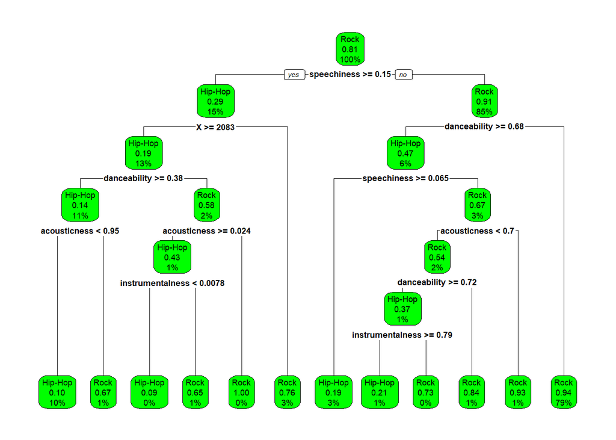

```r
new_grafico_arbol <- rpart.plot(decision_new,box.palette = "green")
```

7.1.1. regresión logística

```r
new_entrenamiento$genre_top <- ifelse(new_entrenamiento$genre_top  == "Hip-Hop", 0, 1)
nuew_prueba$genre_top <- ifelse(nuew_prueba$genre_top  == "Hip-Hop", 0, 1)
new_mr<- glm(genre_top ~ X + acousticness + danceability + instrumentalness +
                          liveness + speechiness , data = new_entrenamiento, family = "binomial")
new_pm<- predict(new_mr, newdata = nuew_prueba, type = "response")

new_predc<- ifelse(new_pm > 0.5, 1, 0)
new_predc<- as.factor(new_predc)
nuew_prueba$genre_top=as.factor(nuew_prueba$genre_top)


new_metrica<- confusionMatrix(new_predc,nuew_prueba$genre_top)
print(new_metrica)
```

```
## Confusion Matrix and Statistics
##
##           Reference
## Prediction    0    1
##          0  286   79
##          1  177 1859
##
##                Accuracy : 0.8934
##                  95% CI : (0.8803, 0.9054)
##     No Information Rate : 0.8072
##     P-Value [Acc > NIR] : < 2.2e-16
##
##                   Kappa : 0.6275
##
##  Mcnemar's Test P-Value : 1.34e-09
##
##             Sensitivity : 0.6177
##             Specificity : 0.9592
##          Pos Pred Value : 0.7836
##          Neg Pred Value : 0.9131
##              Prevalence : 0.1928
##          Detection Rate : 0.1191
##    Detection Prevalence : 0.1520
##       Balanced Accuracy : 0.7885
##
##        'Positive' Class : 0
##
```

```r
Metrics::auc(new_predc,nuew_prueba$genre_top)
```

```
## [1] 0.8483132
```

8. Crear un modelo de regresión logística usando las componentes principales como los datos del modelo. 8.1.Crear un dataset con las componentes principales como variables (escoger al menos seis componentes)

```r
nuevo_data <- as.data.frame(pca_1$ind$coord)
nuevo_data$genre_top=dataFrame$genre_top
```

8.2. Crear los nuevos dataset de entrenamiento y prueba manteniendo la misma semilla y generador usados anteriormente.

```r
pca_Entrenamiento =nuevo_data[info_50, ]
pca_Prueba = nuevo_data[-info_50, ]

pca_Entrenamiento $genre_top <- ifelse(pca_Entrenamiento$genre_top  == "Hip-Hop", 0, 1)
pca_Prueba$genre_top <- ifelse(pca_Prueba$genre_top  == "Hip-Hop", 0, 1)

mr_pca<- glm(genre_top ~ ., data = pca_Entrenamiento, family = "binomial")
prob_50 <- predict(mr_pca, newdata = pca_Prueba, type = "response")

clases_50 <- ifelse(prob_50  > 0.5, 1, 0)
clases_50 <- as.factor(clases_50)
pca_Prueba$genre_top <- as.factor(pca_Prueba$genre_top)
con_50<- confusionMatrix(clases_50, pca_Prueba$genre_top)
print(con_50)
```

```
## Confusion Matrix and Statistics
##
##           Reference
## Prediction    0    1
##          0  255   74
##          1  208 1864
##
##                Accuracy : 0.8825
##                  95% CI : (0.869, 0.8952)
##     No Information Rate : 0.8072
##     P-Value [Acc > NIR] : < 2.2e-16
##
##                   Kappa : 0.576
##
##  Mcnemar's Test P-Value : 2.374e-15
##
##             Sensitivity : 0.5508
##             Specificity : 0.9618
##          Pos Pred Value : 0.7751
##          Neg Pred Value : 0.8996
##              Prevalence : 0.1928
##          Detection Rate : 0.1062
##    Detection Prevalence : 0.1370
##       Balanced Accuracy : 0.7563
##
##        'Positive' Class : 0
##
```

```r
Metrics::auc(clases_50, pca_Prueba$genre_top)
```

```
## [1] 0.8373449
```

8.3. ¿Mejoran los resultados con el PCA? ¿Mejoran los resultados con el PCA?